title: “Identification and diagnosis of outlier samples” author: “Jim Zhang” date: “2016-02-11” output: html_document: fig_caption: yes toc: yes —

This procedure requires the following inputs:

- A data matrix with genes or other variables as rows and samples as columns
- Samples (column names of the data matrix) were split into one to any number of groups, there should be at least 4 samples in each group for the outlier identification to work properly
- Specify the cutoff values of *NMN* (minimal number of samples in each group) and *NSD* (Number of standard deviations).
- Optionally, gene annotation and a collection of predefined gene sets for functional categorization of genes responsible for the outliers

# Project

## Title

Treatment of gas-1 mutated C. Elegans with antioxidant drugs

## Home

http://mybic.chop.edu/labs/falkm/gas1_antioxidant_drugs

## Description

This project uses gene expression microarray data to study effect of antioxidant drugs on C. Elegans worms with gas-1 mutation.

## Data set

The data set includes **16524** genes and **75** samples in **16** groups.

# Analysis and results

## Identification of outliers

The following steps were applied to identify outlier samples:

- Given a data matrix of genes and samples, split samples into predefined sample groups, so each group includes only biological or technical replicates
- Calculate the Pearson’s correlation coeffecients between each pair of samples in the same group, and then the average correlation coefficients of each sample to all the other samples in the same group, *Ms*
- Calculate *NSDi*, or the number of standard deviations, for each sample *(Ms[i]-mean(Ms[-i]))/sd(Ms[-i])*, where *Ms[-i]* is the vector of *Ms* without the sample *i*
- Identify outliers with mean correlation coefficient *Ms[i]* less than **0.99** and **3** standard deviations below mean(Ms[-i])

As a result, *9* outliers were identified

- Click here to view result table
- Outlier IDs: *N2_A_6, N2_A_5, N2_A_1, N2_A_3, Gas1_A_23, CoQ10_L1_50, Lipo_A_18, Lipo_L1_71, NaAc_L1_64*

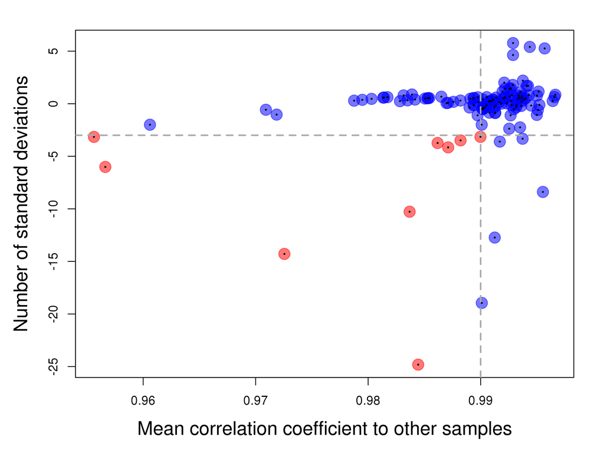

**Figure 1** There were **9** outliers identified from **6** groups (highlighted in red) based on inter-sample correlation.

## Differential expression between outliers and non-outliers

Each outlier was compared to non-outlier samples in the same group to calculate differential expression.

Click on sample ID to view scatterplots that compare the global differential expression of an outlier vs. non-outliers (*left*) and a non-outliers vs. other non-outliers (*right*).

- N2_A_6
- N2_A_5
- N2_A_1
- N2_A_3
- Gas1_A_23
- CoQ10_L1_50
- Lipo_A_18
- Lipo_L1_71
- NaAc_L1_64

The differential expression of each outlier vs. its corresponding non-outliers was compared to each other. High correlation of differential expression between 2 samples suggests that the 2 outliers could be caused by the same reason.

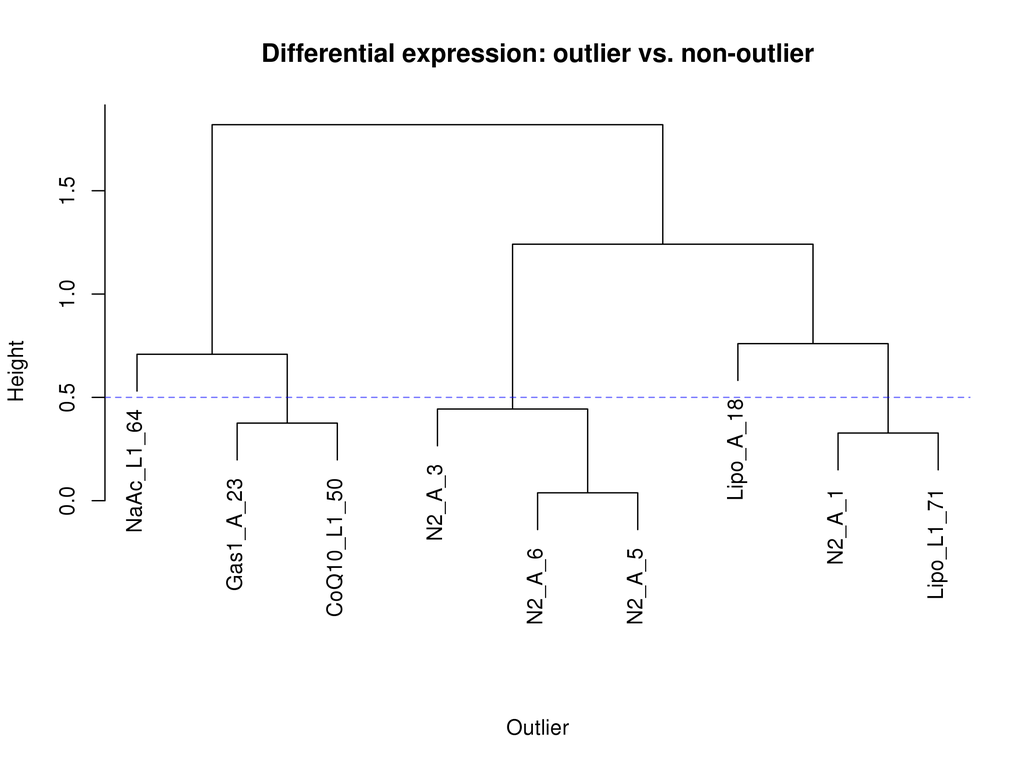

**Figure 2** Clustering of outliers based on their differential expression to corresponding non-outliers.

The following subset(s) of outliers had similar differential expression:

- N2_A_6; N2_A_5; N2_A_3
- N2_A_1; Lipo_L1_71
- Gas1_A_23; CoQ10_L1_50

### Selection of differentially expressed genes (DEGs)

Functional categorization of genes differentially expressed between outliers and corresponding non-outliers could be very suggestive of the cause leading to the outlier. The following steps were used to select DEGs:

- Select two lists of DEGs with higher or lower expression in each outlier comparing to non-outliers in the same sample group
  - The difference between the outlier and the mean of non-outliers is greater than 3 standard deviations of the non-outliers
  - From the remaining genes, pick the top 0.99 with the largest difference between the outlier and non-outliers
  - From the remaining genes, pick those with differential expression greater than 2, or the top 50 genes having the largest differential expression, which ever gives more

The numbers of DEGs selected from each outlier (click on numbers to view full lists):

|  | Higher in outlier | Low in outlier |
| --- | --- | --- |
| N2_A_6 | 250 | 50 |
| N2_A_5 | 250 | 50 |
| N2_A_1 | 122 | 88 |
| N2_A_3 | 50 | 50 |
| Gas1_A_23 | 50 | 50 |
| CoQ10_L1_50 | 50 | 50 |
| Lipo_A_18 | 50 | 50 |
| Lipo_L1_71 | 50 | 56 |
| NaAc_L1_64 | 53 | 50 |

### Gene set enrichment analysis of DEGs

DEGs having higher or lower expression in each outliers were mapped to a collection of predefined genesets downloaded from:

- BioSystems
- KEGG
- MSigDb
- OMIM
- PubTator

Enrichment of DEGs in each gene set was tested by Hypergeometric test. Gene set collection of a few model animals can be downloaded from: https://github.com/zhezhangsh/DEGandMore/tree/master/examples/geneset_collections

Results were saved to /nas/is1/zhangz/projects/falk/2015-01_Worm_Antioxidant_Drugs/results/identify_outlers/outliers.rds.

*END OF DOCUMENT*